# Project Python Foundations: FoodHub Data Analysis

### **Question 7**: Which are the top 5 restaurants in terms of the number of orders received? [1 mark]

```python
df['restaurant_name'].value_counts().head(5)
```

| restaurant_name | count |
| --- | --- |
| Shake Shack | 219 |
| The Meatball Shop | 132 |
| Blue Ribbon Sushi | 119 |
| Blue Ribbon Fried Chicken | 96 |
| Parm | 68 |

**dtype:** int64

a few resturaunts dominate the apps oreders but they may not be the places that give us the best margins under the current pricing scheme we should consider changing the pricing scheme of bins or try to change customer behavior to get them hooked on places that give us better margins under the current pricing structure

#### Observations:

restaurant_name Shake Shack 219 The Meatball Shop 132 Blue Ribbon Sushi 119 Blue Ribbon Fried Chicken 96 Parm 68

### **Question 8**: Which is the most popular cuisine on weekends? [1 mark]

```python
df.groupby('day_of_the_week')['cuisine_type'].value_counts()
```

| day_of_the_week | cuisine_type | count |
| --- | --- | --- |
| Weekday | American | 169 |
|  | Japanese | 135 |
|  | Italian | 91 |
|  | Chinese | 52 |
|  | Indian | 24 |
|  | Mexican | 24 |
|  | Middle Eastern | 17 |
|  | Mediterranean | 14 |
|  | Southern | 6 |
|  | French | 5 |
|  | Thai | 4 |
|  | Vietnamese | 3 |
|  | Korean | 2 |
|  | Spanish | 1 |
| Weekend | American | 415 |
|  | Japanese | 335 |
|  | Italian | 207 |
|  | Chinese | 163 |
|  | Mexican | 53 |
|  | Indian | 49 |
|  | Mediterranean | 32 |
|  | Middle Eastern | 32 |
|  | Thai | 15 |
|  | French | 13 |
|  | Korean | 11 |
|  | Southern | 11 |
|  | Spanish | 11 |
|  | Vietnamese | 4 |

**dtype:** int64

#### Observations: American with 415

its also worth noting that the type of food people doesnt change a whole lot here between the different day of week types

### **Question 9**: What percentage of the orders cost more than 20 dollars? [2 marks]

```python
percentage_over_20 = (len(df[df['cost_of_the_order'] > 20]) / len(df))*100
percentage_over_20
```

```
29.24130663856691
```

#### Observations: 29.24%

### **Question 10**: What is the mean order delivery time? [1 mark]

```python
df['delivery_time'].mean()
```

```
24.161749209694417
```

```python
df.describe()
```

|  | order_id | customer_id | cost_of_the_order | food_preparation_time | delivery_time |
| --- | --- | --- | --- | --- | --- |
| count | 1.898000e+03 | 1898.000000 | 1898.000000 | 1898.000000 | 1898.000000 |
| mean | 1.477496e+06 | 171168.478398 | 16.498851 | 27.371970 | 24.161749 |
| std | 5.480497e+02 | 113698.139743 | 7.483812 | 4.632481 | 4.972637 |
| min | 1.476547e+06 | 1311.000000 | 4.470000 | 20.000000 | 15.000000 |
| 25% | 1.477021e+06 | 77787.750000 | 12.080000 | 23.000000 | 20.000000 |
| 50% | 1.477496e+06 | 128600.000000 | 14.140000 | 27.000000 | 25.000000 |
| 75% | 1.477970e+06 | 270525.000000 | 22.297500 | 31.000000 | 28.000000 |
| max | 1.478444e+06 | 405334.000000 | 35.410000 | 35.000000 | 33.000000 |

#### Observations: 24.1617

### **Question 11:** The company has decided to give 20% discount vouchers to the top 3 most frequent customers. Find the IDs of these customers and the number of orders they placed. [1 mark]

```python
df['customer_id'].value_counts().head(3)
```

| customer_id | count |
| --- | --- |
| 52832 | 13 |
| 47440 | 10 |
| 83287 | 9 |

**dtype:** int64

customer_id 52832: 13 | 47440: 10 | 83287: 9

### **Question 12**: Perform a multivariate analysis to explore relationships between the important variables in the dataset. (It is a good idea to explore relations between numerical variables as well as relations between numerical and categorical variables) [10 marks]

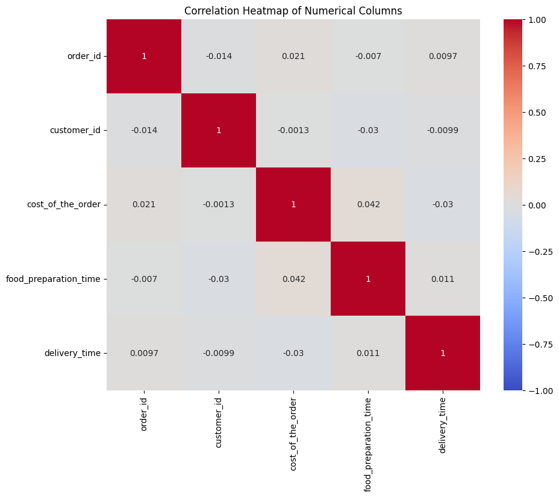

```python
# Calculate the correlation matrix for numerical columns only
correlation_matrix = df.select_dtypes(include=['number']).corr()

plt.figure(figsize=(10, 8))
sns.heatmap(correlation_matrix, annot=True, cmap="coolwarm", vmin=-1, vmax=1)
plt.title("Correlation Heatmap of Numerical Columns")
plt.show()
```

```python
df.groupby(['restaurant_name'])['cost_of_the_order'].sum().sort_values(ascending = False).head(10)
```

| restaurant_name | cost_of_the_order |
| --- | --- |
| Shake Shack | 3579.53 |
| The Meatball Shop | 2145.21 |
| Blue Ribbon Sushi | 1903.95 |
| Blue Ribbon Fried Chicken | 1662.29 |
| Parm | 1112.76 |
| RedFarm Broadway | 965.13 |
| RedFarm Hudson | 921.21 |
| TAO | 834.50 |
| Han Dynasty | 755.29 |
| Blue Ribbon Sushi Bar & Grill | 666.62 |

**dtype:** float64

a small number of resturaunts/chains get the most sales

```python
df.groupby(['restaurant_name'])['cost_of_the_order'].mean().sort_values(ascending = False).head(10)
```

| restaurant_name | cost_of_the_order |
| --- | --- |
| Kambi Ramen House | 32.930000 |
| Emporio | 31.430000 |
| Bhatti Indian Grill | 31.115000 |
| Haru Gramercy Park | 29.830000 |
| Lucky Strike | 29.250000 |
| Il Bambino | 29.250000 |
| Sarabeth's | 29.133333 |
| Rohm Thai | 29.100000 |
| Klong | 29.050000 |
| 67 Burger | 29.050000 |

**dtype:** float64

none of the most visited resturaunts are ones with the highest average costs we should promote them to get our margins up! many of these resturaunts people probably havent tried and may be '6 star compared to what they have been eating' we should promote the ones with 5 star ratings, in popular cuisine types, and above the average price threashold for our current pricing models to take a larger cut but not too high.

```python
#df.groupby(['restaurant_name'])['rating'].mean().sort_values(ascending = False).head(10)
#you can drop the nulls and change it to int to run this
```

day of the week vs restaurant name

[figure not shown]

```python
sns.countplot(data=df, x='day_of_the_week', hue='restaurant_name')
plt.title("Order Frequency")
plt.legend(title='Restaurant')
plt.legend(loc='upper left', bbox_to_anchor=(1, 1), frameon=False, fontsize='small', title='Legend')
```

the type of day only slightly alters the resturaunt people eat at but it does obviously impact the frequency of the eating we should analyze traffic times and try to do promotions for resturaunts that will cut down on both delivery time and preparation time